# *Prediction of electricity demand*

## *Scenario*

*You are employed by Enercoop, a cooperative society that has developed thanks to the liberalization of the electricity market in France. It specializes in renewable energies. Most of these renewable energies, however, are intermittent, so it is difficult to predict the capacity of electricity production. In addition, the demand for electricity users varies over time, and depends on parameters such as weather (temperature, brightness, etc.). The challenge is to match supply and demand!*

## Skills

- Linear regression
- Time series (AR, MA, ARMA, ARIMA)
- Master the ARMA method
- Graph a time series
- Master the methods of smoothing and Holt-Winters metho
- Master the notions of components and decomposition models

**0. Part 0 - Data description**

- 1. Data Preparation
- 2. Data Cleaning
- 3. Data description

**I. Part 1 - Correction of monthly consumption data of temperature effect (due to electric heating) by linear regression**.

- 1. Linear Regression
- 2. Correction of the monthly consumption data of the temperature effect

**II. Part 2 - Seasonal adjustment of consumption obtained after correction, using moving averages**

**III. Part 3 - Prediction of consumption (corrected for the temperature effect) over one year by the Holt Winters method (exponential smoothing) and the SARIMA method on the time series**

- 1. Holt Winters method (exponential smoothing)
- 2. SARIMA Method

**IV. Part 4 - Going Further**

# Bibliography

- https://abcdr.thinkr.fr/comment-separer-les-elements-dun-vecteur-en-plusieurs-colonnes-colsplit/
- https://www.developpez.net/forums/d1851428/autres-langages/autres-langages/r/decroise-table-transformer-plusieurs-variables-seul-modalites/
- https://statistique-et-logiciel-r.com/la-regression-lineaire-simple-avec-le-logiciel-r/
- https://stackoverflow.com/questions/6242955/converting-year-and-month-yyyy-mm-format-to-a-date
- https://stackoverflow.com/questions/40833809/add-legend-to-geom-line-graph-in-r/40834306
- https://otexts.com/fpp2/seasonal-arima.html
- https://rpubs.com/riazakhan94/arima_with_example
- https://www.datascience.com/blog/introduction-to-forecasting-with-arima-in-r-learn-data-science-tutorials
- https://datascienceplus.com/time-series-analysis-using-arima-model-in-r/
- https://robjhyndman.com/hyndsight/arimaconstants/

## Part 0 - Data description

## 1. Data Preparation

```r
library("ggplot2")
library(latex2exp)
library(forecast)
library(reshape2)
install.packages("caschrono")
install.packages("zoo")
library(caschrono)
```

```r
dju <- read.csv("data/dju.csv", header=TRUE, sep=';',na.strings=c(""))
cons <- read.csv("data/consommation.csv", header=TRUE, sep=';',na.strings=c(""))
```

Sources :

- cons : http://www.rte-france.com/fr/eco2mix/eco2mix-telechargement
- dju : https://cegibat.grdf.fr/simulateur/calcul-dju

### cons : Monthly electricity consumption

```r
# We only keep interesting columns.
cons <- cons[,c(1,3,14)]

# For the city of Nantes, only the data concerning Pays de la Loire are kept
cons <- subset(cons, Territoire == 'Pays-de-la-Loire')

# We remove unnecessary lines.
cons <- subset(cons, Mois != '0000-00')
cons <- subset(cons, Consommation.totale != 0)

# separate the elements of a vector into several columns
vars <- colsplit(cons$Mois, "-", c("year", "month"))
cons <- cbind(vars,cons)
cons <- cons[,c(1,2,3,5)]

# We rename the Consumption.total column
names(cons)[3] <- "date"
names(cons)[4] <- "consumption"

# Creating the date column for temporal representations
cons <- transform(cons, date = as.Date(paste(date,"-01",sep="")))

head(cons)
```

A data.frame: 6 × 4

|  | year <int> | month <int> | date <date> | consumption <int> |
| --- | --- | --- | --- | --- |
| 218 | 2014 | 1 | 2014-01-01 | 2875 |
| 231 | 2014 | 2 | 2014-02-01 | 2618 |
| 244 | 2014 | 3 | 2014-03-01 | 2495 |
| 257 | 2014 | 4 | 2014-04-01 | 2099 |
| 270 | 2014 | 5 | 2014-05-01 | 1920 |
| 283 | 2014 | 6 | 2014-06-01 | 1809 |

### dju : Weather data

```r
dju
```

A data.frame: 6 × 14

| X <int> | JAN <dbl> | FÉV <dbl> | MAR <dbl> | AVR <dbl> | MAI <dbl> | JUN <dbl> | JUI <dbl> | AOÛ <dbl> | SEP <dbl> | OCT <dbl> | NOV <dbl> | DÉC <dbl> | TOTAL <dbl> |
| --- | --- | --- | --- | --- | --- | --- | --- | --- | --- | --- | --- | --- | --- |
| 2013 | 377.5 | 358.8 | 334.4 | 236.0 | 174.0 | 54.4 | 3.2 | 1.0 | 37.5 | 91.1 | 275.1 | 339.7 | 2282.5 |
| 2014 | 300.1 | 268.0 | 257.5 | 169.8 | 127.5 | 23.9 | 5.1 | 32.0 | 14.5 | 81.9 | 194.4 | 337.7 | 1812.2 |
| 2015 | 357.2 | 350.6 | 275.1 | 145.4 | 119.9 | 23.3 | 11.1 | 11.8 | 74.3 | 167.8 | 163.6 | 240.4 | 1940.1 |
| 2016 | 317.1 | 301.1 | 309.5 | 239.9 | 109.4 | 36.9 | 13.8 | 5.2 | 16.9 | 183.8 | 263.7 | 355.0 | 2152.2 |
| 2017 | 426.7 | 269.9 | 217.8 | 207.6 | 77.7 | 18.0 | 4.1 | 16.1 | 73.9 | 95.3 | 277.5 | 335.2 | 2019.5 |
| 2018 | 283.8 | 385.9 | 297.3 | 156.2 | 80.4 | 0.0 | 0.0 | 0.0 | 0.0 | 0.0 | 0.0 | 0.0 | 1203.4 |

```r
# The TOTAL column is removed.
dju <- dju[,c(1:13)]

# We rename the first column.
names(dju)[1] <- "year"

# We rename the month columns.
for ( i in 1:12)
{
    names(dju)[i+1] <- i
}

# We uncross the table
dju <- melt(dju, id.vars=c('year'), mesure.vars=c(2:13), variable.name="month",value.name="DJU")
dju <- transform(dju, month = as.integer(month))

# Null data removed after May 2018
dju <- subset(dju, DJU != 0)

head(dju)
```

A data.frame: 6 × 3

| year <int> | month <int> | DJU <dbl> |
| --- | --- | --- |
| 2013 | 1 | 377.5 |
| 2014 | 1 | 300.1 |
| 2015 | 1 | 357.2 |
| 2016 | 1 | 317.1 |
| 2017 | 1 | 426.7 |
| 2018 | 1 | 283.8 |

## 2. Data Cleaning

### Data structure

```r
str(cons)
```

```
'data.frame':	64 obs. of  4 variables:
 $ year       : int  2014 2014 2014 2014 2014 2014 2014 2014 2014 2014 ...
 $ month      : int  1 2 3 4 5 6 7 8 9 10 ...
 $ date       : Date, format: "2014-01-01" "2014-02-01" ...
 $ consumption: int  2875 2618 2495 2099 1920 1809 1894 1693 1806 1987 ...
```

```r
str(dju)
```

```
'data.frame':	65 obs. of  3 variables:
 $ year : int  2013 2014 2015 2016 2017 2018 2013 2014 2015 2016 ...
 $ month: int  1 1 1 1 1 1 2 2 2 2 ...
 $ DJU  : num  378 300 357 317 427 ...
```

The variables are in the right format.

### Missing data

```r
sapply(cons, function(x) sum(is.na(x)))
```

**year**

0

**month**

0

**date**

0

**consumption**

0

```r
sapply(dju, function(x) sum(is.na(x)))
```

**year**

0

**month**

0

**DJU**

0

No data is missing.

### Aberrant and atypical variables

```r
summary(cons)
```

```
      year          month            date             consumption
 Min.   :2014   Min.   : 1.00   Min.   :2014-01-01   Min.   :1693
 1st Qu.:2015   1st Qu.: 3.00   1st Qu.:2015-04-23   1st Qu.:1871
 Median :2016   Median : 6.00   Median :2016-08-16   Median :2152
 Mean   :2016   Mean   : 6.25   Mean   :2016-08-15   Mean   :2280
 3rd Qu.:2017   3rd Qu.: 9.00   3rd Qu.:2017-12-08   3rd Qu.:2632
 Max.   :2019   Max.   :12.00   Max.   :2019-04-01   Max.   :3351
```

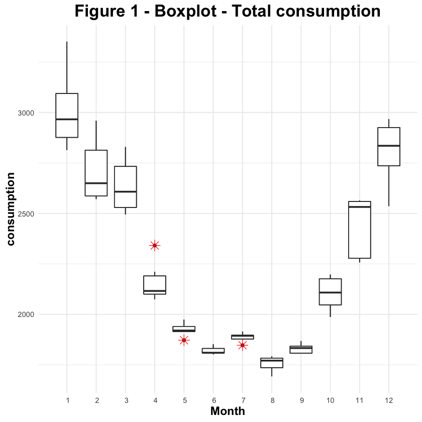

```r
cons_boxplot <- ggplot(cons, aes(x=month, y=consumption,group=month))+ geom_boxplot(fill="gray") +
                    scale_x_discrete(limits=c(1:12))+  labs(x="Month", y = "consumption") +
                    theme_minimal() + geom_boxplot(outlier.colour="red", outlier.shape=8, outlier.size=4) +
                    labs(title = "Figure 1 - Boxplot - Total consumption") +
                    theme(plot.title = element_text(size=20, face="bold",hjust = 0.5),axis.title.x = element_text(color="black", size=14, face="bold",hjust = 0.5),axis.title.y = element_text(color="black", size=14, face="bold",vjust = 0.5)) +
                    ggsave("figure/Figure 1 - Boxplot - Total consumption.png", width = 8, height = 9)
cons_boxplot
```

We note that the electricity consumption is higher in winter (logical because it is colder, so you have to heat more), with great variations (probably because the winters are not as cold from one year to another ).

```r
summary(dju)
```

```
      year          month             DJU
 Min.   :2013   Min.   : 1.000   Min.   :  1.0
 1st Qu.:2014   1st Qu.: 3.000   1st Qu.: 37.5
 Median :2015   Median : 6.000   Median :169.8
 Mean   :2015   Mean   : 6.231   Mean   :175.6
 3rd Qu.:2017   3rd Qu.: 9.000   3rd Qu.:283.8
 Max.   :2018   Max.   :12.000   Max.   :426.7
```

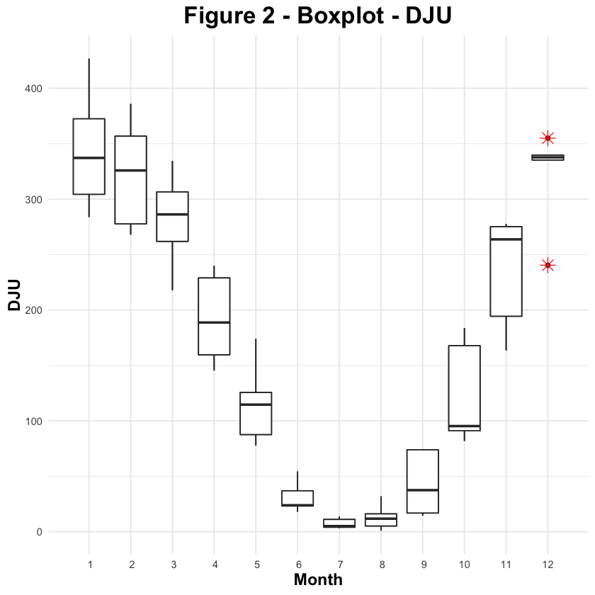

```r
dju_boxplot <- ggplot(dju, aes(x=month, y=DJU,group=month))+ geom_boxplot(fill="gray") +
                    scale_x_discrete(limits=c(1:12))+  labs(x="Month", y = "DJU") +
                    theme_minimal() + geom_boxplot(outlier.colour="red", outlier.shape=8, outlier.size=4) +
                    labs(title = "Figure 2 - Boxplot - DJU") +
                    theme(plot.title = element_text(size=20, face="bold",hjust = 0.5),axis.title.x = element_text(color="black", size=14, face="bold",hjust = 0.5),axis.title.y = element_text(color="black", size=14, face="bold",vjust = 0.5)) +
                    ggsave("figure/Figure 2 - Boxplot - DJU.png", width = 8, height = 9)
dju_boxplot
```

## 3. Data description

```r
# multiplot : Plotting multiple graphs

multiplot <- function(..., plotlist=NULL, file, cols=1, layout=NULL) {
  library(grid)

  # Make a list from the ... arguments and plotlist
  plots <- c(list(...), plotlist)

  numPlots = length(plots)

  # If layout is NULL, then use 'cols' to determine layout
  if (is.null(layout)) {
    # Make the panel
    # ncol: Number of columns of plots
    # nrow: Number of rows needed, calculated from # of cols
    layout <- matrix(seq(1, cols * ceiling(numPlots/cols)),
                    ncol = cols, nrow = ceiling(numPlots/cols))
  }

 if (numPlots==1) {
    print(plots[[1]])

  } else {
    # Set up the page
    grid.newpage()
    pushViewport(viewport(layout = grid.layout(nrow(layout), ncol(layout))))

    # Make each plot, in the correct location
    for (i in 1:numPlots) {
      # Get the i,j matrix positions of the regions that contain this subplot
      matchidx <- as.data.frame(which(layout == i, arr.ind = TRUE))

      print(plots[[i]], vp = viewport(layout.pos.row = matchidx$row,
                                      layout.pos.col = matchidx$col))
    }
  }
}
```

```r
data_cons <- merge(cons, dju, by.x=c("year", "month"), by.y=c("year", "month"))
data_cons <- data_cons[order(data_cons$year, data_cons$month),]
```

**pdf:** 2

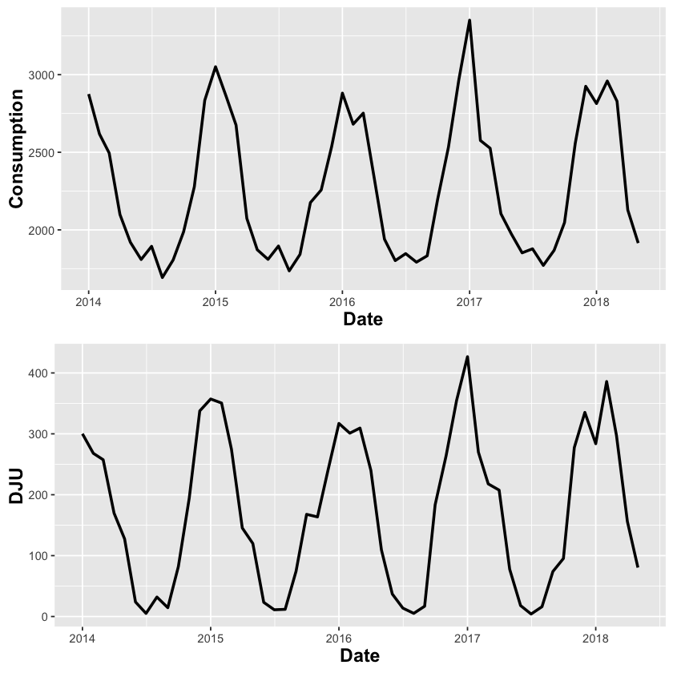

```r
plot_cons <- ggplot()+
    geom_line(data=data_cons,aes(y=consumption,x= date),size=1 )+
    labs(x="Date", y = "Consumption") +
    theme(plot.title = element_text(size=13, face="bold",hjust = 0.5),axis.title.x = element_text(color="black", size=14, face="bold",hjust = 0.5),axis.title.y = element_text(color="black", size=14, face="bold",vjust = 0.5))

plot_dju <- ggplot()+
    geom_line(data=data_cons,aes(y=DJU,x= date),size=1) +
    labs(x="Date", y = "DJU") +
    theme(plot.title = element_text(size=13, face="bold",hjust = 0.5),axis.title.x = element_text(color="black", size=14, face="bold",hjust = 0.5),axis.title.y = element_text(color="black", size=14, face="bold",vjust = 0.5))

# Sauvegarder la figure
png("figure/Figure 3 - Consumption and DJU evolutions.png", width = 16, height = 9, units = 'in', res = 300)
multiplot(plot_cons, plot_dju, cols=1)
dev.off()

# Afficher la figure
multiplot(plot_cons, plot_dju, cols=1)
```

Consumption shows:

- a stable trend over time
- a seasonality, that is to say, regular variations around the average level, of period 12 (corresponding to an annual period since the series is monthly):
  - the maximum consumption corresponds to the months of December-January-February: logical because it is the winter period where the heating is activated
  - the minimum consumption corresponds to the months of July-August: logical because it is the summer period

[figure not shown]

## Part 1 - Correction of monthly consumption data of temperature effect (due to electric heating) by linear regression.

## 1. Linear Regression

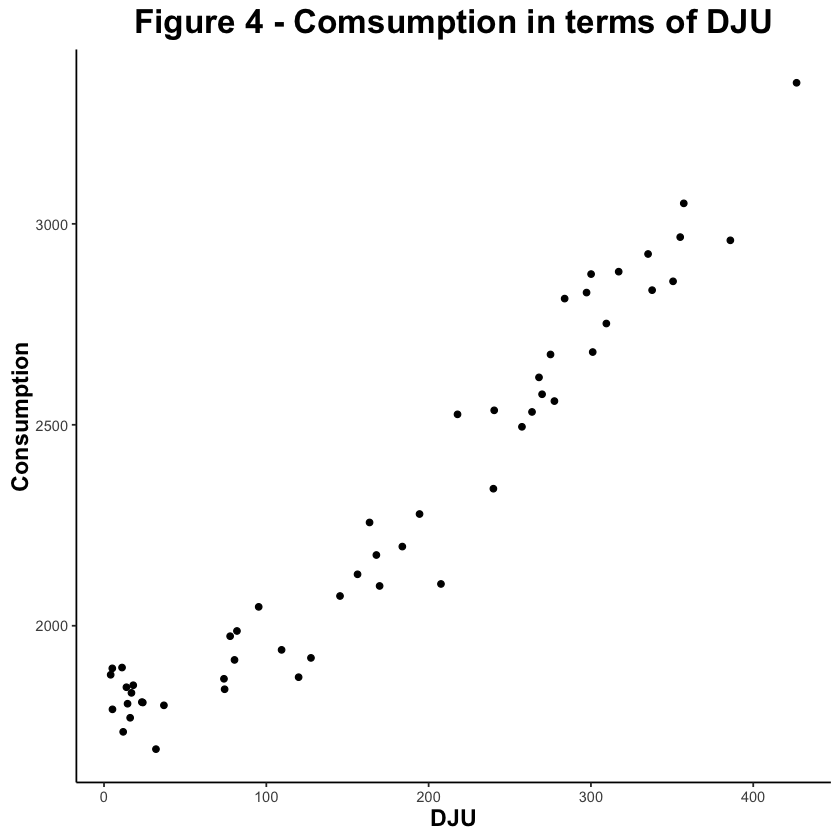

```r
cons_dju_plot <- ggplot(data_cons, aes(x=DJU, y=consumption))+ geom_point() +
                    labs(x="DJU", y = "Consumption") +
                    theme_classic() +
                    labs(title = "Figure 4 - Comsumption in terms of DJU") +
                    theme(plot.title = element_text(size=20, face="bold",hjust = 0.5),axis.title.x = element_text(color="black", size=14, face="bold",hjust = 0.5),axis.title.y = element_text(color="black", size=14, face="bold",vjust = 0.5)) +
                    ggsave("figure/Figure 4 - Comsumption in terms of DJU.png", width = 16, height = 9)
cons_dju_plot
```

There is a linear correlation between consumption and the DJU. Performing a linear regression will allow us to correct the monthly consumption data of the temperature effect (due to electric heating).

```r
regr <- lm(consumption ~ DJU, data = data_cons)
summary(regr)
```

```
Call:
lm(formula = consumption ~ DJU, data = data_cons)

Residuals:
     Min       1Q   Median       3Q      Max
-295.054  -75.853    8.616   86.962  201.681

Coefficients:
             Estimate Std. Error t value Pr(>|t|)
(Intercept) 1688.1672    26.4539   63.82   <2e-16 ***
DJU            3.4243     0.1241   27.59   <2e-16 ***
---
Signif. codes:  0 ‘***’ 0.001 ‘**’ 0.01 ‘*’ 0.05 ‘.’ 0.1 ‘ ’ 1

Residual standard error: 113.4 on 51 degrees of freedom
Multiple R-squared:  0.9372,	Adjusted R-squared:  0.936
F-statistic: 760.9 on 1 and 51 DF,  p-value: < 2.2e-16
```

```r
pearson = cor(data_cons$consumption,data_cons$DJU, method="pearson")
cat("Pearson correlation coefficient  : ", round(pearson,2))
```

```
Pearson correlation coefficient  :  0.97
```

### Results analysis

Prob (F-statistic) < 5%: The model is significant.

P-value: DJU: < 5%: The coefficients are significant with a 95% confidence interval.

Pearson correlation coefficient: 0.97: There is a strong linear correlation between consumption and the DJU.

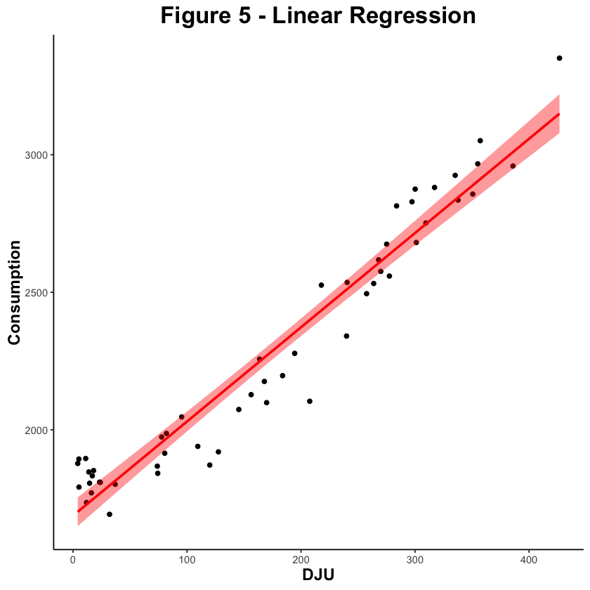

```r
regr_plot <- ggplot(data_cons, aes(y=consumption, x=DJU))+
                geom_point()+
                geom_smooth(colour="red", method="lm", fill="red") +
                labs(x="DJU", y = "Consumption") +
                theme_classic() +
                labs(title = "Figure 5 - Linear Regression") +
                theme(plot.title = element_text(size=20, face="bold",hjust = 0.5),axis.title.x = element_text(color="black", size=14, face="bold",hjust = 0.5),axis.title.y = element_text(color="black", size=14, face="bold",vjust = 0.5)) +
                ggsave("figure/Figure 5 - Linear Regression.png", width = 16, height = 9)
regr_plot
```

## Verification of validity assumptions of linear regression

### Assessment of independence

**pdf:** 2

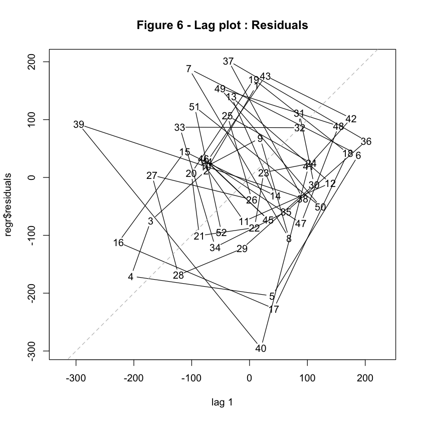

```r
# Save figure
png("figure/Figure 6 - Lag plot : Residuals.png", width = 16, height = 9, units = 'in', res = 300)
lag.plot(regr$residuals, main="Figure 6 - Lag plot : Residuals")
dev.off()

# Plotting figure
lag.plot(regr$residuals, main="Figure 6 - Lag plot : Residuals")
```

```r
library(car)
durbinWatsonTest(regr)
```

```
 lag Autocorrelation D-W Statistic p-value
   1      0.06463625      1.828503   0.462
 Alternative hypothesis: rho != 0
```

The independence or not of the residues can be represented with the lag plot which represents the value of the residue n + 1 as a function of the value of the residue n. To have a dependence between the residues, a well-defined form must be observed, which is not the case. Moreover, the Durbin Watson statistic is close to 2 p-value> 5%, which is characteristic of an independence of residues: the hypothesis of independence of the residues is thus verified.

### Hypothesis of normality of residues

This hypothesis can be evaluated graphically using a QQplot. If the residues are well distributed along the line on the plot, then the assumption of normality is accepted. Conversely, if they deviate, then the hypothesis of normality is rejected

**pdf:** 2

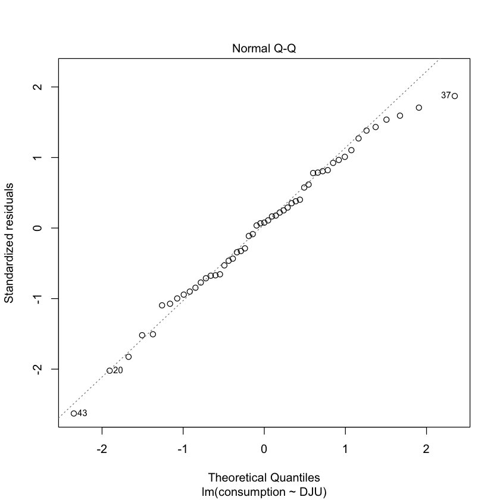

```r
# Save figure
png("figure/Figure 7 - QQ plot : Residuals.png", width = 16, height = 9, units = 'in', res = 300)
plot(regr,2)
dev.off()

# Plotting figure
plot(regr,2)
```

Here, the points are pretty well aligned on the line. The Shapiro-Wilk test can also be used to assess the normality of residues. The normality assumption is rejected if the p-value is less than 0.05.

```r
shapiro.test(regr$residuals)
```

```
	Shapiro-Wilk normality test

data:  regr$residuals
W = 0.98414, p-value = 0.7014
```

We have a p-value> 5% which leads us to accept the hypothesis H0: the residues are normally distributed.

### Residue homogeneity hypothesis

This hypothesis can be verified in a visual way. It is necessary to realize a "residuals vs fitted plot". The "fitted" correspond to the responses predicted by the model, for the observed values of the predicitive variable. More precisely, for this plot, the square root of the standardized residues is used.

**pdf:** 2

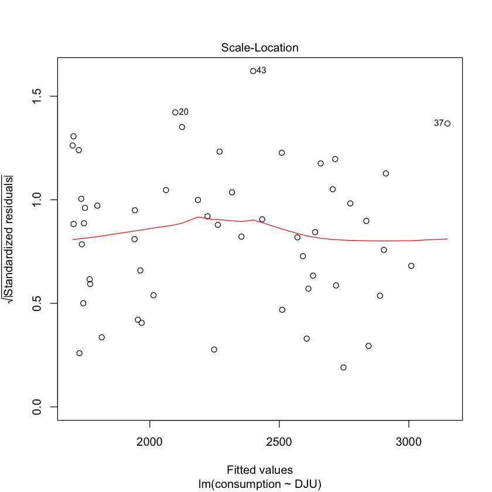

```r
# Save figure
png("figure/Figure 8 - Scale-Location : Residuals.png", width = 16, height = 9, units = 'in', res = 300)
plot(regr, 3)
dev.off()

# Plotting figure
plot(regr, 3)
```

Here, the red curve is generally flat. This shows that the residuals tend to be homogeneously distributed throughout the gradient of predicted prestige values. And so the hypothesis of homogeneity of residues is accepted. It is also possible to evaluate this hypothesis using the Breush-Pagan test. The homogeneity assumption is rejected if the p-value is less than 0.05.

```r
ncvTest(regr)
```

```
Non-constant Variance Score Test
Variance formula: ~ fitted.values
Chisquare = 0.005807538, Df = 1, p = 0.93925
```

Here, the test does not reject the assumption of homogeneity either.

## 2. Correction of monthly consumption data of the temperature effect

```r
data_cons$consumption_corrected <- data_cons$consumption - regr$coefficients[2]*data_cons$DJU
head(data_cons)
```

A data.frame: 6 × 6

|  | year <int> | month <int> | date <date> | consumption <int> | DJU <dbl> | consumption_corrected <dbl> |
| --- | --- | --- | --- | --- | --- | --- |
| 1 | 2014 | 1 | 2014-01-01 | 2875 | 300.1 | 1847.365 |
| 5 | 2014 | 2 | 2014-02-01 | 2618 | 268.0 | 1700.286 |
| 6 | 2014 | 3 | 2014-03-01 | 2495 | 257.5 | 1613.241 |
| 7 | 2014 | 4 | 2014-04-01 | 2099 | 169.8 | 1517.553 |
| 8 | 2014 | 5 | 2014-05-01 | 1920 | 127.5 | 1483.401 |
| 9 | 2014 | 6 | 2014-06-01 | 1809 | 23.9 | 1727.159 |

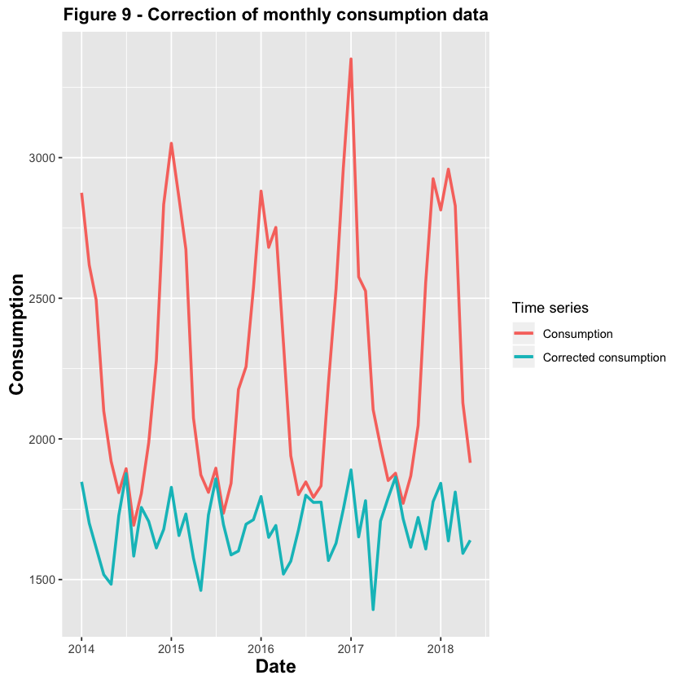

```r
plot_correction <- ggplot()+
    geom_line(data=data_cons,aes(y=consumption,x= date,colour="darkblue"),size=1 )+
    geom_line(data=data_cons,aes(y=consumption_corrected,x= date,colour="red"),size=1) +
    scale_color_discrete(name = "Time series", labels = c("Consumption", "Corrected consumption"))+
    labs(x="Date", y = "Consumption") +
    labs(title = "Figure 9 - Correction of monthly consumption data") +
    theme(plot.title = element_text(size=13, face="bold",hjust = 0.5),axis.title.x = element_text(color="black", size=14, face="bold",hjust = 0.5),axis.title.y = element_text(color="black", size=14, face="bold",vjust = 0.5)) +
    ggsave("figure/Figure 9 - Correction of monthly consumption data.png", width = 16, height = 9)

plot_correction
```

## Part 2 - Seasonal adjustment of consumption obtained after correction, using moving averages

[figure not shown]

### Analysis of the additive decomposition of time series

```r
consumption = ts(data_cons[,c(4)], start=c(2014, 1), end=c(2018, 5), frequency = 12)
decompose_cons = decompose(consumption, "additive")

consumption_corr  = ts(data_cons[,c(6)], start=c(2014, 1), end=c(2018, 5), frequency = 12)
decompose_cons_corr = decompose(consumption_corr , "additive")
```

**pdf:** 2

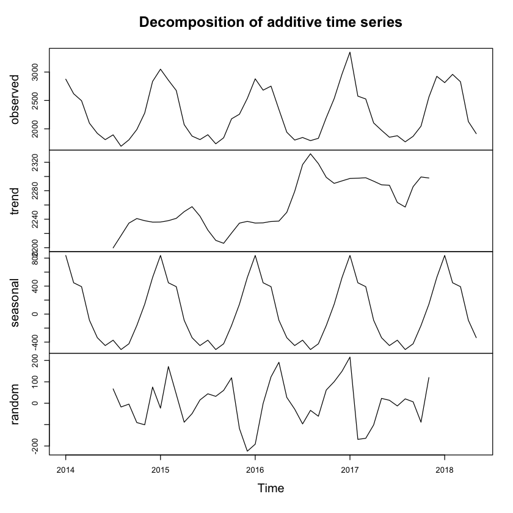

```r
# Save figure
png("figure/Figure 10 - Consumption - Decomposition of additive time series.png", width = 8, height = 9, units = 'in', res = 300)
plot(decompose_cons)
dev.off()

# Plot figure
plot(decompose_cons)
```

The time series representing the monthly consumption is the sum of 3 time series: **Time series = Trend + Seasonality + Residuals**

seasonality of 12 months

white noise

**pdf:** 2

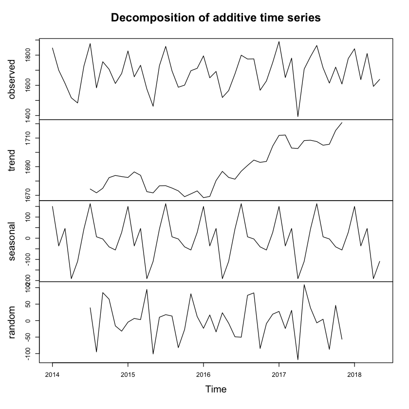

```r
# Save figure
png("figure/Figure 11 - Corrected consumption - Decomposition of additive time series.png", width = 8, height = 9, units = 'in', res = 300)
plot(decompose_cons_corr)
dev.off()

# Plot figure
plot(decompose_cons_corr)
```

### Seasonal adjustment: Moving Averages

The seasonal adjustment of the time series (of period 12) by moving averages consists of subtracting the time series of seasonality from the original time series.

```r
consumption_cvs = consumption-decompose_cons$seasonal
consumption_corr_cvs = consumption_corr-decompose_cons_corr$seasonal
```

**pdf:** 2

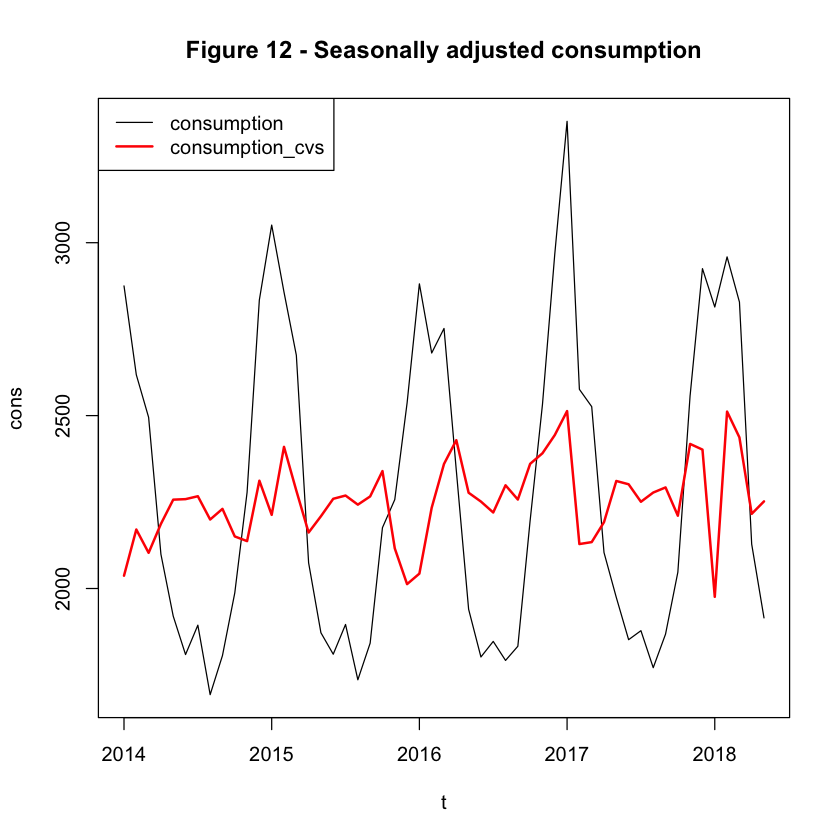

```r
# Save figure
png("figure/Figure 12 - Seasonally adjusted consumption.png", width = 8, height = 9, units = 'in', res = 300)
ts.plot(consumption, consumption_cvs, xlab="t", ylab="cons",col=c(1,2),lwd=c(1,2))
legend("topleft",legend=c("consumption","consumption_cvs"), col=c(1,2),lwd=c(1,2))
title("Figure 12 - Seasonally adjusted consumption")
dev.off()

# Plot figure
ts.plot(consumption, consumption_cvs, xlab="t", ylab="cons",col=c(1,2),lwd=c(1,2))
legend("topleft",legend=c("consumption","consumption_cvs"), col=c(1,2),lwd=c(1,2))
title("Figure 12 - Seasonally adjusted consumption")
```

**pdf:** 2

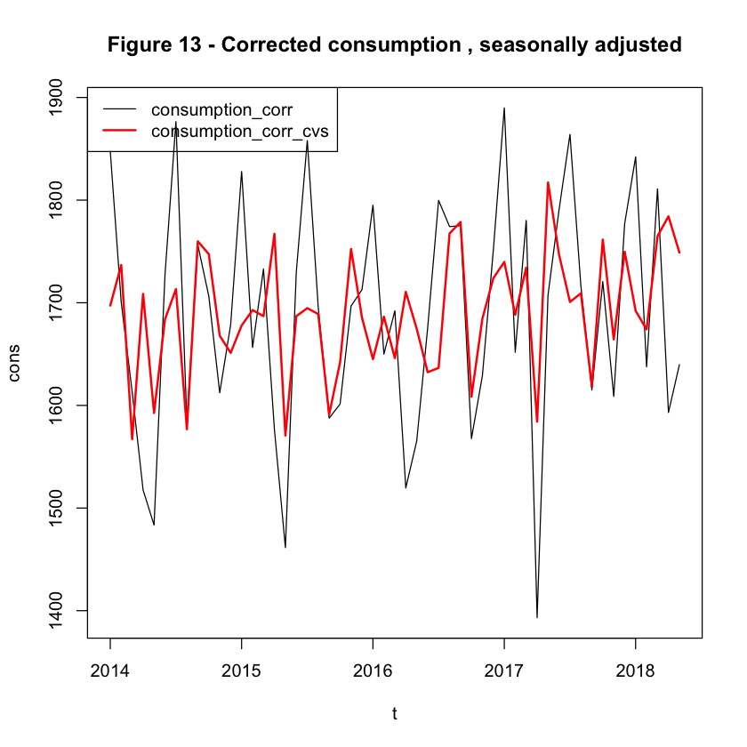

```r
# Save figure
png("figure/Figure 13 - Corrected consumption , seasonally adjusted.png", width = 8, height = 9, units = 'in', res = 300)
ts.plot(consumption_corr, consumption_corr_cvs, xlab="t", ylab="cons",col=c(1,2),lwd=c(1,2))
legend("topleft",legend=c("consumption_corr","consumptionn_corr_cvs"), col=c(1,2),lwd=c(1,2))
title("Figure 13 - Corrected consumption , seasonally adjusted")
dev.off()

# Plot figure
ts.plot(consumption_corr, consumption_corr_cvs, xlab="t", ylab="cons",col=c(1,2),lwd=c(1,2))
legend("topleft",legend=c("consumption_corr","consumption_corr_cvs"), col=c(1,2),lwd=c(1,2))
title("Figure 13 - Corrected consumption , seasonally adjusted")
```

## Part 3 - Prediction of consumption (corrected for the temperature effect) over one year by the Holt Winters method (exponential smoothing) and the SARIMA method on the time series

## 1. Holt Winters method (exponential smoothing)

### Modeling

The Holt-Winters method, sometimes still used in practice, consists in supposing that Xt is approximate near T by aT + (t-T) bT + ST, where S is the period of the seasonal cycle of the time series.

```r
hw=ets(consumption_corr,model="AAA")
```

The model used 'AAA' allows to decompose the time series into an error (1st A) + a trend (2nd A) + a seasonality (3rd A). A: for "Additive"

```r
summary(hw)
```

```
ETS(A,A,A)

Call:
 ets(y = consumption_corr, model = "AAA")

  Smoothing parameters:
    alpha = 0.0187
    beta  = 0.0038
    gamma = 0.0086

  Initial states:
    l = 1673.5495
    b = 0.9072
    s = 27.4373 -55.5862 -40.8301 -3.5413 6.6356 163.2166
           43.3091 -109.1987 -181.9031 46.046 -36.4709 140.8859

  sigma:  70.2461

     AIC     AICc      BIC
676.0912 693.5769 709.5861

Training set error measures:
                   ME     RMSE      MAE        MPE     MAPE      MASE
Training set 2.940484 58.69285 46.26865 0.04594965 2.802309 0.6407592
                   ACF1
Training set -0.2186901
```

As alpha> gamma> beta, what has the most influence in the model of Holt Winters for realization at a time T is the previous moment, then the seasonality, then the trend.

### Prediction using the Holt Winters model over one year

**pdf:** 2

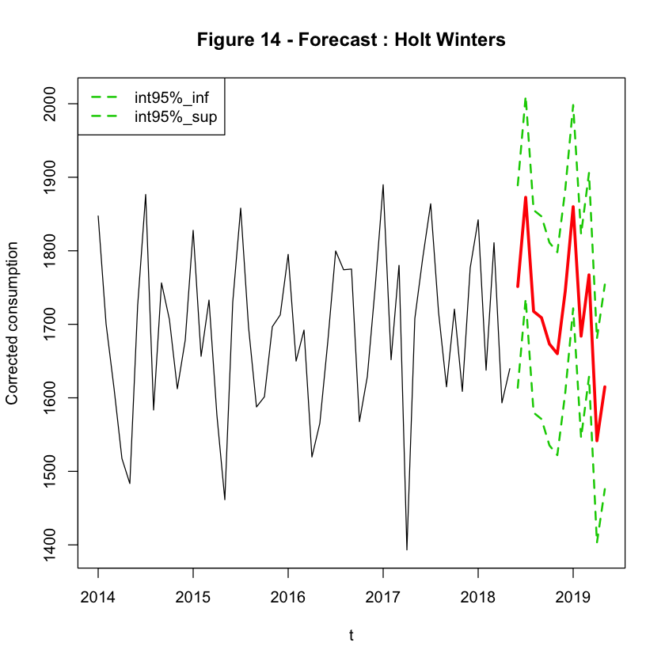

```r
pred_model_hw=forecast(hw,h=12,level=95)
pred_hw=pred_model_hw$mean
pred_hw_l=ts(pred_model_hw$lower,start=c(2018,6),frequency=12)
pred_hw_u=ts(pred_model_hw$upper,start=c(2018,6),frequency=12)

# Save figure
png("figure/Figure 14 - Forecast : Holt Winters.png", width = 8, height = 9, units = 'in', res = 300)
ts.plot(consumption_corr,pred_hw,pred_hw_l,pred_hw_u,xlab="t",ylab="Corrected consumption",col=c(1,2,3,3),lty=c(1,1,2,2),lwd=c(1,3,2,2))
legend("topleft",legend=c("int95%_inf","int95%_sup"),col=c(3,3),lty=c(2,2),lwd=c(2,2))
title("Figure 14 - Forecast : Holt Winters")
dev.off()

# Plot figure
ts.plot(consumption_corr,pred_hw,pred_hw_l,pred_hw_u,xlab="t",ylab="Corrected consumption",col=c(1,2,3,3),lty=c(1,1,2,2),lwd=c(1,3,2,2))
legend("topleft",legend=c("int95%_inf","int95%_sup"),col=c(3,3),lty=c(2,2),lwd=c(2,2))
title("Figure 14 - Forecast : Holt Winters")
```

**pdf:** 2

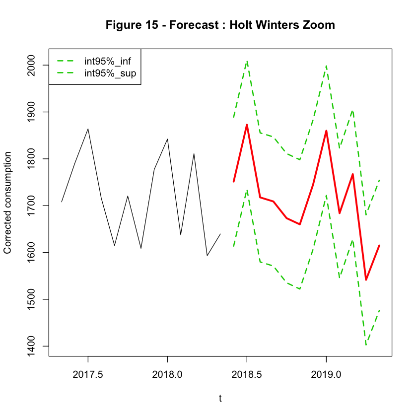

```r
# Sauvegarder la figure
png("figure/Figure 15 - Forecast : Holt Winters Zoom.png", width = 16, height = 9, units = 'in', res = 300)
ts.plot(window(consumption_corr,start=c(2017,5)),pred_hw,pred_hw_l,pred_hw_u,xlab="t",ylab="Corrected consumption",col=c(1,2,3,3),lty=c(1,1,2,2),lwd=c(1,3,2,2))
legend("topleft",legend=c("int95%_inf","int95%_sup"),col=c(3,3),lty=c(2,2),lwd=c(2,2))
title("Figure 15 - Forecast : Holt Winters Zoom")
dev.off()

# Afficher la figure
ts.plot(window(consumption_corr,start=c(2017,5)),pred_hw,pred_hw_l,pred_hw_u,xlab="t",ylab="Corrected consumption",col=c(1,2,3,3),lty=c(1,1,2,2),lwd=c(1,3,2,2))
legend("topleft",legend=c("int95%_inf","int95%_sup"),col=c(3,3),lty=c(2,2),lwd=c(2,2))
title("Figure 15 - Forecast : Holt Winters Zoom")
```

### Retrospective Analysis

The series of the period [May 2017 - May 2018] is truncated, which we seek to predict from the historical [January 2014 - April 2017]

```r
x_tronc=window(consumption_corr,end=c(2017,4))
x_a_prevoir=window(consumption_corr,start=c(2017,5))

modelhwtronc=ets(x_tronc,model="AAA")
```

**pdf:** 2

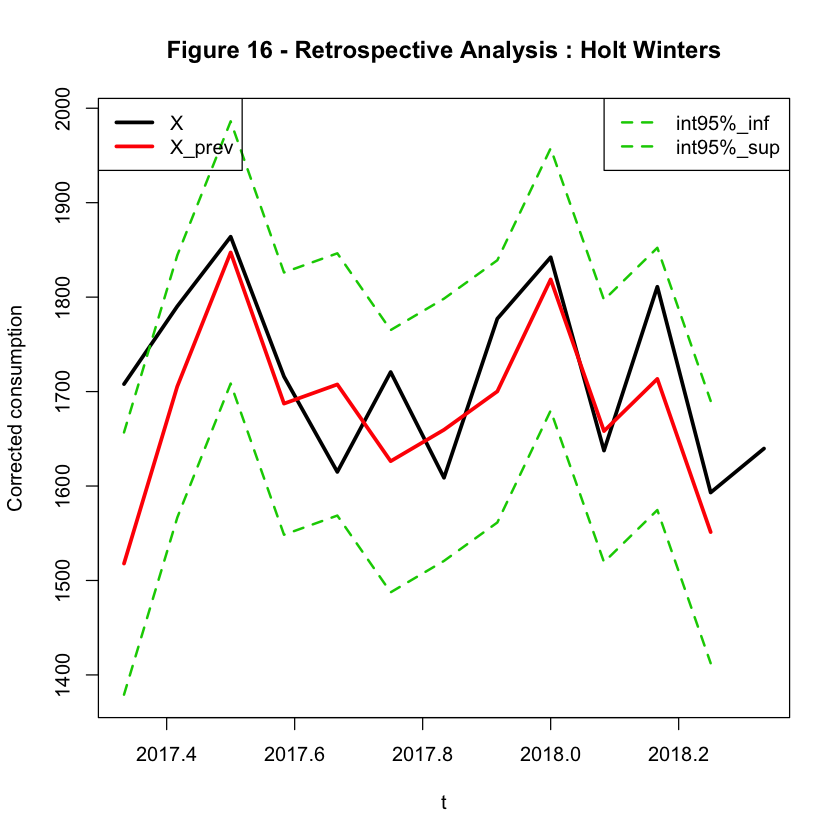

```r
pred_modelhwtronc=forecast(modelhwtronc,h=12,level=95)
predhw_tronc=pred_modelhwtronc$mean
predhw_l_tronc=ts(pred_modelhwtronc$lower,start=c(2017,5),frequency=12)
predhw_u_tronc=ts(pred_modelhwtronc$upper,start=c(2017,5),frequency=12)

# Save figure
png("figure/Figure 16 - Retrospective Analysis : Holt Winters.png", width = 16, height = 9, units = 'in', res = 300)
ts.plot(x_a_prevoir,predhw_tronc,predhw_l_tronc,predhw_u_tronc,xlab="t",ylab="Corrected consumption",col=c(1,2,3,3),lty=c(1,1,2,2),lwd=c(3,3,2,2))
legend("topleft",legend=c("X","X_prev"),col=c(1,2,3,3),lty=c(1,1),lwd=c(3,3))
legend("topright",legend=c("int95%_inf","int95%_sup"),col=c(3,3),lty=c(2,2),lwd=c(2,2))
title("Figure 16 - Retrospective Analysis : Holt Winters")
dev.off()

# Afficher la figure
ts.plot(x_a_prevoir,predhw_tronc,predhw_l_tronc,predhw_u_tronc,xlab="t",ylab="Corrected consumption",col=c(1,2,3,3),lty=c(1,1,2,2),lwd=c(3,3,2,2))
legend("topleft",legend=c("X","X_prev"),col=c(1,2,3,3),lty=c(1,1),lwd=c(3,3))
legend("topright",legend=c("int95%_inf","int95%_sup"),col=c(3,3),lty=c(2,2),lwd=c(2,2))
title("Figure 16 - Retrospective Analysis : Holt Winters")
```

```r
rmsehw=sqrt(mean((x_a_prevoir-predhw_tronc)^2))
cat('RMSE hw :', round(rmsehw,2))
```

```
RMSE hw : 82.97
```

```r
mapehw=mean(abs(1-predhw_tronc/x_a_prevoir))*100
cat('MAPE hw :', round(mapehw,2))
```

```
MAPE hw : 3.97
```

The interpretation of the error criteria depends on the series and the forecast quality required. In this case, an MAPE of 3.97% seems satisfactory a priori.

## 2. SARIMA method

Our time series Consumption has a trend and seasonality so it depends on time. So it can not be modeled by an ARMA stationary process. We will therefore stationarize the time series by differentiation.

### Stationnarisation

**pdf:** 2

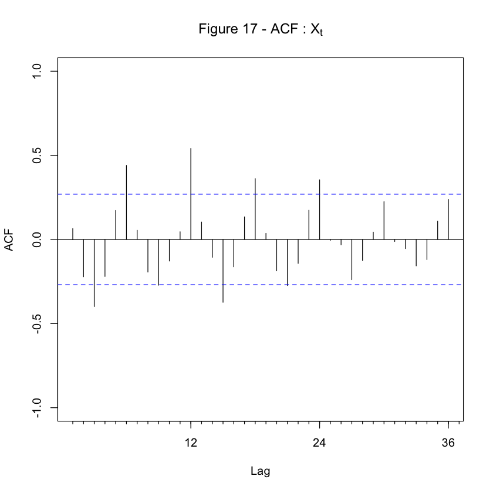

```r
# Save figure
png("figure/Figure 17 - ACF : Xt.png", width = 16, height = 9, units = 'in', res = 300)
Acf(consumption_corr,lag.max=36,ylim=c(-1,1),main=TeX("Figure 17 - ACF : X_t$"))
dev.off()

# Plot figure
Acf(consumption_corr,lag.max=36,ylim=c(-1,1),main=TeX("Figure 17 - ACF : X_t$"))
```

By observing the simple autocorrelogram of the time series consumption:

Simple autocorrelations ρ (h) are neither close to 1 nor close to each other. Thus we do not differentiate in trend.

The ACF output of the series shows a slow decrease towards 0 for the multiples of 12. Similar behaviors of simple autorrelations ρ (h) are observed periodically. Indeed, ρ (12) and ρ (24) are quite close, there is a strong correlation / relationship between separate implementations of 12 months. We then perform a differentiation in "seasonality" with s = 12 : differentiation (I-B ^ 12).

**pdf:** 2

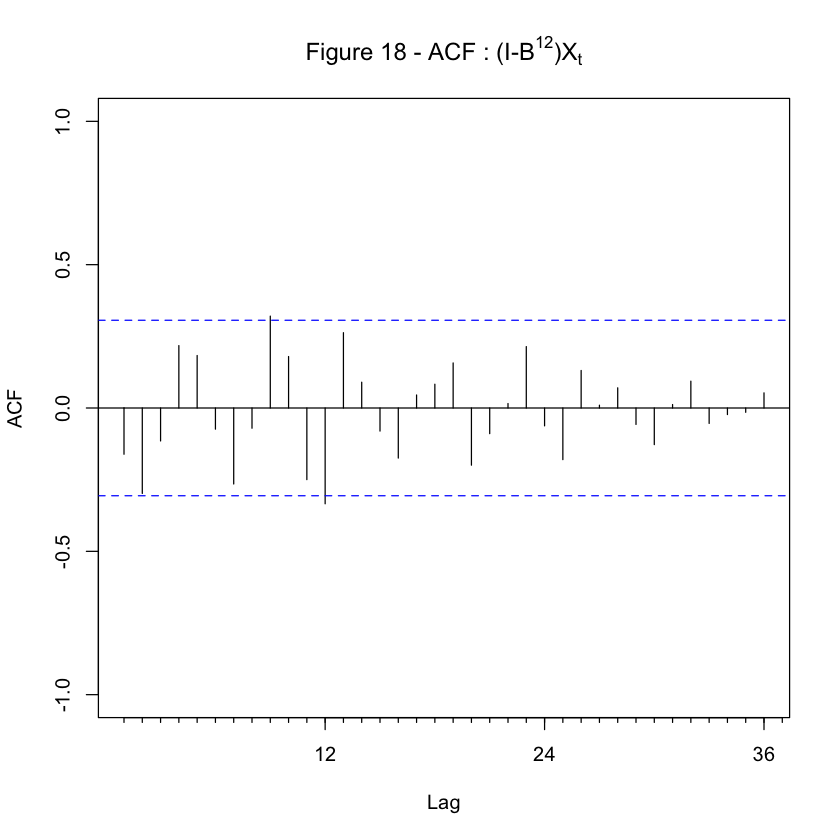

```r
consumption_corr_dif_12= diff(consumption_corr,lag=12,differences=1)

# Save figure
png("figure/Figure 18 - ACF : (I-B^12)Xt.png", width = 8, height = 4.5, units = 'in', res = 300)
Acf(consumption_corr_dif_12,lag.max=36,ylim=c(-1,1),main=TeX("Figure 18 - ACF : $(I-B^{12})X_t$"))
dev.off()

# Plot figure
Acf(consumption_corr_dif_12,lag.max=36,ylim=c(-1,1),main=TeX("Figure 18 - ACF : $(I-B^{12})X_t$"))
```

The ACF output of the seasonally differentiated series seems to be interpreted as a simple empirical autocorrelogram. We will therefore identify an ARMA model on the series (I-B ^ 12) Xt.

On the other hand, the ndiffs () and nsdiffs () functions of R give the best number of differentiations to be made, respectively in trend and seasonality.

```r
d = ndiffs(consumption_corr)
D = nsdiffs(consumption_corr)

cat('d : Optimal number of differentiations in tendency to perform :', d,'\n')
cat('D : Optimal number of seasonal differentiations to be made :', D)
```

```
d : Optimal number of differentiations in tendency to perform : 0
D : Optimal number of seasonal differentiations to be made : 1
```

### Model identification, estimation and validation

At the end of the stationarization, we obtain a stationary process. There is a theoretical result, called Wold decomposition, which tells us that any stationary process can be modeled by an ARMA process. We can devote ourselves to the potential choices of the polynomial coefficients (p, q, P and Q) by relying respectively on the partial autocorrelogram and the simple autocorrelogram estimated:

Determination of AR (p) If our differentiated time series (in trend and / or seasonality) is a process AR (p), then a realization X_t only depends on X_ (t-1), X_ (t-2), ... X_ (tp) realizations preceding.

[figure not shown]

So X_t has no relation with the realizations X_ (t-p-1) ... X_1. Thus, on the partial autocorrelogram, from the rank p + 1, the r (h) are zero. The r (h) being the autocorrelations between time t and t-h conditionally at intermediate times.

** Determination of MA (q) ** If our differentiated time series (in trend and / or seasonality) is a MA (q) process, then an X_t realization can be written as a linear combination of decorrelated disturbances: a white noise and its past.

[figure not shown]

So X_t has no connection with the variations of the realizations X_ (t-q-1) ... X_1. Thus, on the simple autocorrelogram, from the rank q + 1, the ρ (h) are zero.

### Determination of ARs (P) and MAs (Q)

The seasonal part of the AR or MA models can be observed by looking at the seasonal lags (12,24 ...) of the ACP and the PACF.

For example: an ARIMA model (0,0,0) (0,0,1) [12] will have:

- a peak at lag 12 in the ACF but no other significant peaks
- a decrease in seasonal lags in the PACF (ie lags 12, 24, 36 ...)

For example: an ARIMA model (0,0,0) (1,0,0) [12] will have:

- a decrease in seasonal lags in the ACF (ie lags 12, 24, 36 ...)
- a peak at lag 12 in the PACF but no other significant peaks

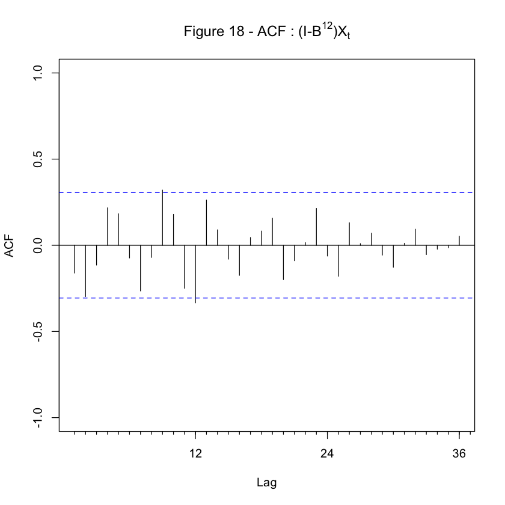

```r
# Plot figure
Acf(consumption_corr_dif_12,lag.max=36,ylim=c(-1,1),main=TeX("Figure 18 - ACF : $(I-B^{12})X_t$"))
```

**pdf:** 2

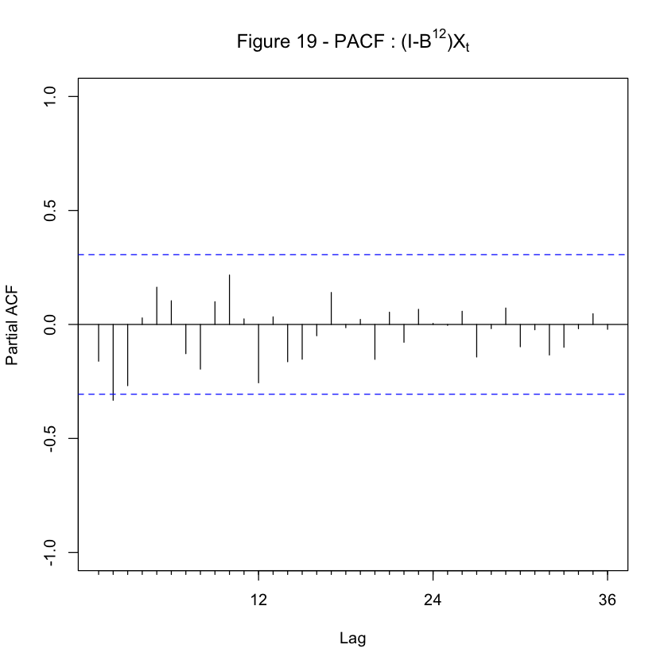

```r
# Save figure
png("figure/Figure 19 - PACF : (I-B^12)Xt.png", width = 8, height = 4.5, units = 'in', res = 300)
Pacf(consumption_corr_dif_12,lag.max=36,ylim=c(-1,1),main=TeX("Figure 19 - PACF : $(I-B^{12})X_t$"))
dev.off()

# Plot figure
Pacf(consumption_corr_dif_12,lag.max=36,ylim=c(-1,1),main=TeX("Figure 19 - PACF : $(I-B^{12})X_t$"))
```

The blue dashed lines are the boundaries of significance (95%). We have :

P = 1 because:

- a decrease in seasonal lags in the ACF (ie lags 12, 24, 36 ...)
- a peak at lag 12 in the PACF but no other significant peaks

q = 0 because: from lag 1, simple autocorrelations are not significant

Q = 1 because:

- a peak at lag 12 in the ACF but no other significant peaks
- a decrease in seasonal lags in the PACF (ie lags 12, 24, 36 ...)

### Model 1 : SARIMA(0,0,0)(1,1,1)[12]

```r
model1=Arima(consumption_corr,order=c(0,0,0),list(order=c(1,1,1),period=12),include.mean=FALSE,method="CSS-ML")
summary(model1)
```

```
Series: consumption_corr
ARIMA(0,0,0)(1,1,1)[12]

Coefficients:
         sar1     sma1
      -0.1536  -0.3768
s.e.   0.4447   0.4572

sigma^2 estimated as 6395:  log likelihood=-238.53
AIC=483.06   AICc=483.71   BIC=488.2

Training set error measures:
                   ME     RMSE    MAE       MPE     MAPE      MASE       ACF1
Training set 12.88354 68.59616 49.294 0.6643798 2.950213 0.6826563 -0.1965251
```

```r
t_stat(model1)
```

A matrix: 2 × 2 of type dbl

|  | sar1 | sma1 |
| --- | --- | --- |
| t.stat | -0.345281 | -0.824198 |
| p.val | 0.729883 | 0.409827 |

P-values > 5%: The coefficients sar1 and sma1 are not significantly different from 0. We then test other models.

### Model 2 : SARIMA(0,0,0)(0,1,1)[12]

```r
model2=Arima(consumption_corr,order=c(0,0,0),list(order=c(0,1,1),period=12),include.mean=FALSE,method="CSS-ML")
summary(model2)
```

```
Series: consumption_corr
ARIMA(0,0,0)(0,1,1)[12]

Coefficients:
         sma1
      -0.5229
s.e.   0.2018

sigma^2 estimated as 6203:  log likelihood=-238.58
AIC=481.16   AICc=481.48   BIC=484.59

Training set error measures:
                   ME     RMSE      MAE       MPE     MAPE      MASE       ACF1
Training set 12.79084 68.41941 49.40324 0.6596748 2.955604 0.6841691 -0.1908856
```

```r
t_stat(model2)
```

A matrix: 2 × 1 of type dbl

|  | sma1 |
| --- | --- |
| t.stat | -2.591086 |
| p.val | 0.009567 |

The coefficient is significant.

**pdf:** 2

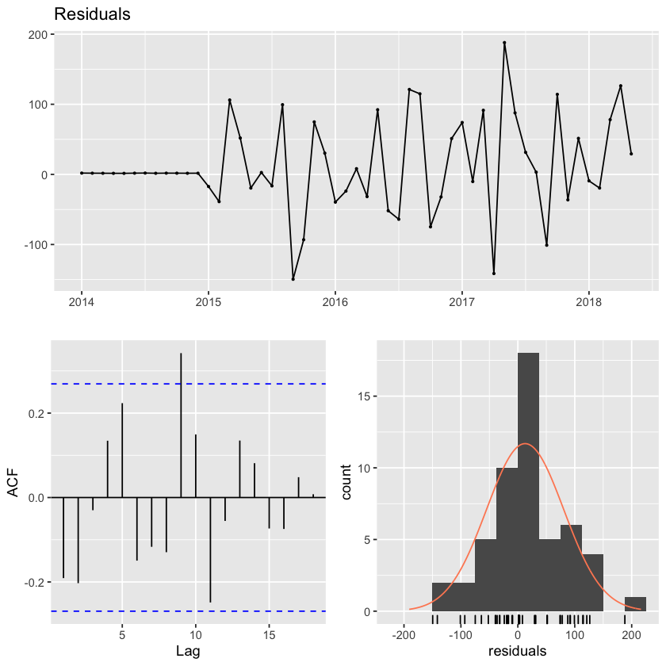

```r
# Save figure
png("figure/Figure 20 - Residuals : SARIMA 2.png", width = 8, height = 9, units = 'in', res = 300)
checkresiduals(model2$residuals)
dev.off()

# Plot figure
checkresiduals(model2$residuals)
```

```r
shapiro.test(model2$residuals)
```

```
	Shapiro-Wilk normality test

data:  model2$residuals
W = 0.96552, p-value = 0.1287
```

```r
Box.test.2(model2$residuals,nlag=c(6,12,18,24,30,36),type="Ljung-Box",decim=2)
```

A matrix: 6 × 2 of type dbl

| Retard | p-value |
| --- | --- |
| 6 | 0.18 |
| 12 | 0.05 |
| 18 | 0.18 |
| 24 | 0.33 |
| 30 | 0.48 |
| 36 | 0.75 |

### Model 3 : SARIMA(0,0,0)(1,1,0)[12]

```r
model3=Arima(consumption_corr,order=c(0,0,0),list(order=c(1,1,0),period=12),include.mean=FALSE,method="CSS-ML")
summary(model3)
```

```
Series: consumption_corr
ARIMA(0,0,0)(1,1,0)[12]

Coefficients:
         sar1
      -0.4595
s.e.   0.1567

sigma^2 estimated as 6456:  log likelihood=-238.93
AIC=481.87   AICc=482.18   BIC=485.29

Training set error measures:
                   ME     RMSE      MAE       MPE     MAPE      MASE       ACF1
Training set 12.51396 69.80473 49.72159 0.6416264 2.976506 0.6885778 -0.1905193
```

```r
t_stat(model3)
```

A matrix: 2 × 1 of type dbl

|  | sar1 |
| --- | --- |
| t.stat | -2.932709 |
| p.val | 0.003360 |

The coefficient is significant.

**pdf:** 2

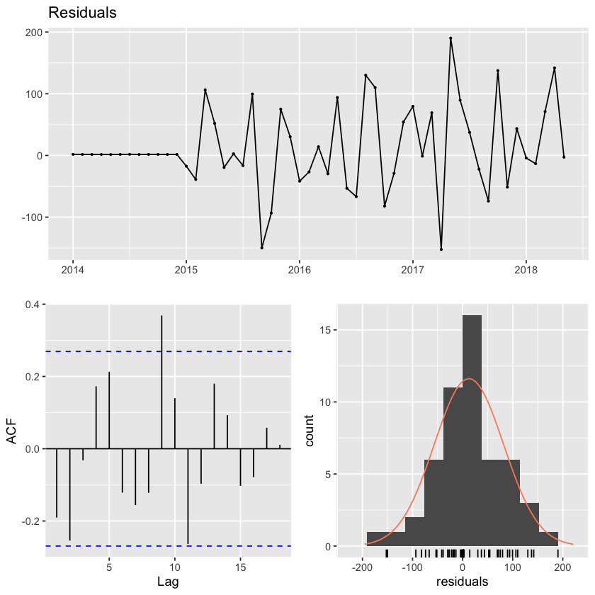

```r
# Save figure
png("figure/Figure 21 - Residuals : SARIMA 3.png", width = 8, height = 9, units = 'in', res = 300)
checkresiduals(model3$residuals)
dev.off()

# Plot figure
checkresiduals(model3$residuals)
```

The normality of the residues must be verified. Graphically, the residues seem to follow a normal distribution. A null hypothesis Shapiro-Wilk test is performed H0 (residues are normally distributed). We have a p-value > 5% which leads us to accept the hypothesis H0: the residues are normally distributed

```r
shapiro.test(model3$residuals)
```

```
	Shapiro-Wilk normality test

data:  model3$residuals
W = 0.96424, p-value = 0.113
```

```r
Box.test.2(model3$residuals,nlag=c(6,12,18,24,30,36),type="Ljung-Box",decim=2)
```

A matrix: 6 × 2 of type dbl

| Retard | p-value |
| --- | --- |
| 6 | 0.12 |
| 12 | 0.02 |
| 18 | 0.06 |
| 24 | 0.13 |
| 30 | 0.25 |
| 36 | 0.51 |

### Model auto : auto.arima

The auto.arima () function of the forecast package automatically generates the optimal coefficients (p, d, q) (P, D, Q). The function involves models and looks for the combination that minimizes the AIC (Akaike Information Criteria): it is a measure of the information lost by the model. The weaker it is, the better the model.

```r
model_auto <- auto.arima(consumption_corr, stepwise=TRUE, approximation=TRUE, allowdrift=FALSE)
```

```r
summary(model_auto)
```

```
Series: consumption_corr
ARIMA(0,0,0)(0,1,1)[12]

Coefficients:
         sma1
      -0.5229
s.e.   0.2018

sigma^2 estimated as 6203:  log likelihood=-238.58
AIC=481.16   AICc=481.48   BIC=484.59

Training set error measures:
                   ME     RMSE      MAE       MPE     MAPE      MASE       ACF1
Training set 12.79084 68.41941 49.40324 0.6596748 2.955604 0.6841691 -0.1908856
```

Note that the model determined using the auto.arima () function corresponds to model 2. Among our 3 models, it is the only one:

Whose whiteness test is fully validated.

In addition, the AIC of model 2 is lower than the AIC of model 3.

### Prediction using the selected model (2) over one year

**pdf:** 2

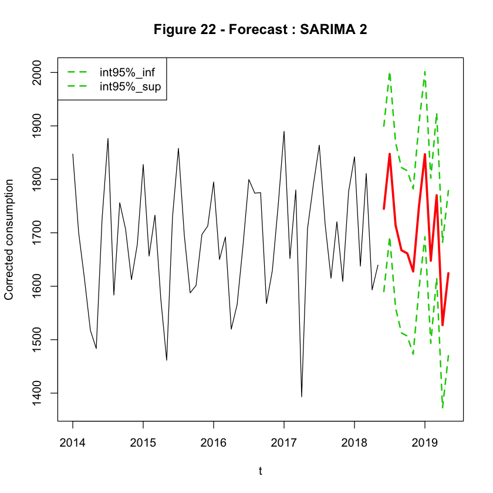

```r
pred_model2=forecast(model2,h=12,level=95)
pred2=pred_model2$mean
pred2_l=ts(pred_model2$lower,start=c(2018,6),frequency=12)
pred2_u=ts(pred_model2$upper,start=c(2018,6),frequency=12)

# Save figure
png("figure/Figure 22 - Forecast : SARIMA 2.png", width = 16, height = 9, units = 'in', res = 300)
ts.plot(consumption_corr,pred2,pred2_l,pred2_u,xlab="t",ylab="Corrected consumption",col=c(1,2,3,3),lty=c(1,1,2,2),lwd=c(1,3,2,2))
legend("topleft",legend=c("int95%_inf","int95%_sup"),col=c(3,3),lty=c(2,2),lwd=c(2,2))
title("Figure 22 - Forecast : SARIMA 2")
dev.off()

# Plot figure
ts.plot(consumption_corr,pred2,pred2_l,pred2_u,xlab="t",ylab="Corrected consumption",col=c(1,2,3,3),lty=c(1,1,2,2),lwd=c(1,3,2,2))
legend("topleft",legend=c("int95%_inf","int95%_sup"),col=c(3,3),lty=c(2,2),lwd=c(2,2))
title("Figure 22 - Forecast : SARIMA 2")
```

**pdf:** 2

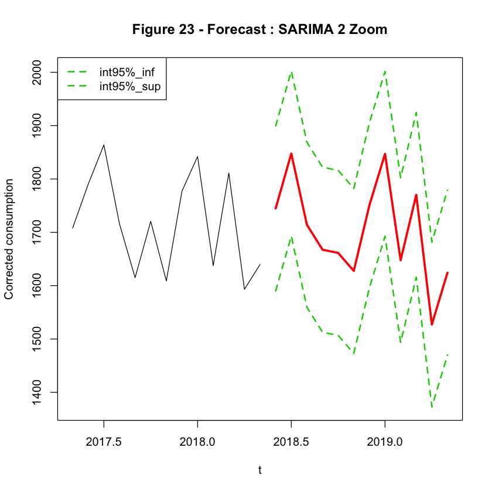

```r
# Save figure
png("figure/Figure 23 - Forecast : SARIMA 2 Zoom.png", width = 16, height = 9, units = 'in', res = 300)
ts.plot(window(consumption_corr,start=c(2017,5)),pred2,pred2_l,pred2_u,xlab="t",ylab="Corrected consumption",col=c(1,2,3,3),lty=c(1,1,2,2),lwd=c(1,3,2,2))
legend("topleft",legend=c("int95%_inf","int95%_sup"),col=c(3,3),lty=c(2,2),lwd=c(2,2))
title("Figure 23 - Forecast : SARIMA 2 Zoom")
dev.off()

# Plot figure
ts.plot(window(consumption_corr,start=c(2017,5)),pred2,pred2_l,pred2_u,xlab="t",ylab="Corrected consumption",col=c(1,2,3,3),lty=c(1,1,2,2),lwd=c(1,3,2,2))
legend("topleft",legend=c("int95%_inf","int95%_sup"),col=c(3,3),lty=c(2,2),lwd=c(2,2))
title("Figure 23 - Forecast : SARIMA 2 Zoom")
```

### Retrospective Analysis

The series of the period [May 2017 - May 2018] is truncated, which we seek to predict from the historical [January 2014 - April 2017]

```r
x_tronc=window(consumption_corr,end=c(2017,4))
x_to_predict=window(consumption_corr,start=c(2017,5))
```

```r
model2tronc=Arima(x_tronc,order=c(0,0,0),list(order=c(0,1,1),period=12),include.mean=FALSE,method="CSS-ML")
summary(model2tronc)
```

```
Series: x_tronc
ARIMA(0,0,0)(0,1,1)[12]

Coefficients:
         sma1
      -0.3958
s.e.   0.3369

sigma^2 estimated as 6000:  log likelihood=-162.02
AIC=328.04   AICc=328.52   BIC=330.7

Training set error measures:
                   ME     RMSE      MAE       MPE    MAPE      MASE       ACF1
Training set 3.530741 63.64063 44.47661 0.1041821 2.68194 0.6693387 -0.1463636
```

```r
t_stat(model2tronc)
```

A matrix: 2 × 1 of type dbl

|  | sma1 |
| --- | --- |
| t.stat | -1.174752 |
| p.val | 0.240094 |

**pdf:** 2

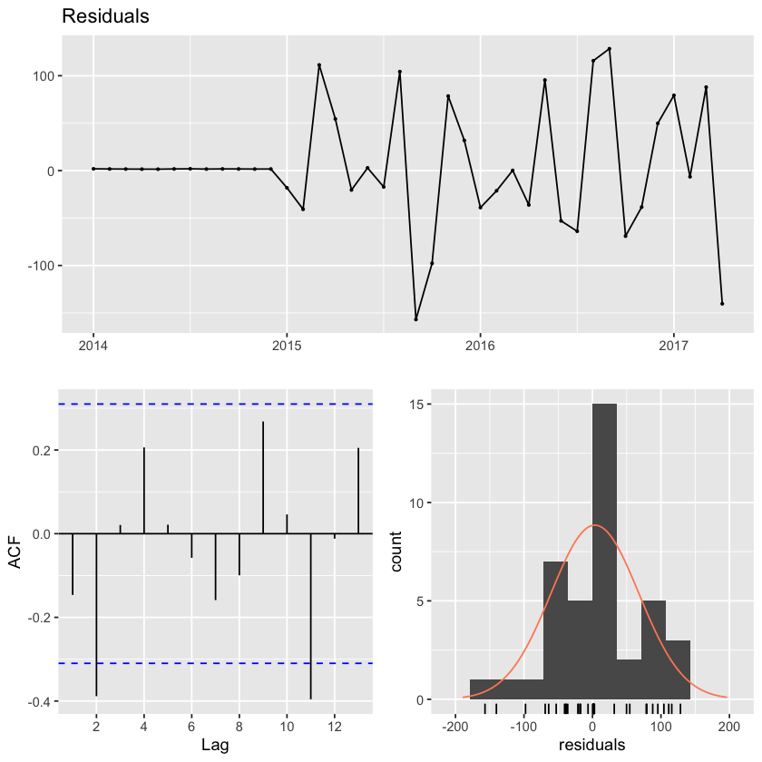

```r
# Save figure
png("figure/Figure 24 - Residuals : SARIMA 2 Retrospective Analysis.png", width = 8, height = 9, units = 'in', res = 300)
checkresiduals(model2tronc$residuals)
dev.off()

# Plot figure
checkresiduals(model2tronc$residuals)
```

```r
shapiro.test(model2tronc$residuals)
```

```
	Shapiro-Wilk normality test

data:  model2tronc$residuals
W = 0.93881, p-value = 0.03153
```

```r
Box.test.2(model2tronc$residuals,nlag=c(6,12,18,24,30,36),type="Ljung-Box",decim=5)
```

A matrix: 6 × 2 of type dbl

| Retard | p-value |
| --- | --- |
| 6 | 0.18731 |
| 12 | 0.07930 |
| 18 | 0.20708 |
| 24 | 0.47208 |
| 30 | 0.75231 |
| 36 | 0.92845 |

**pdf:** 2

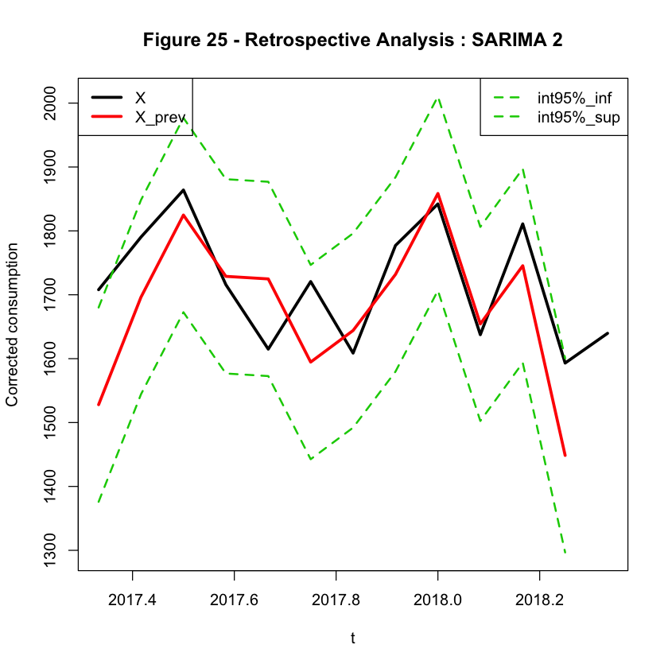

```r
pred_model2tronc=forecast(model2tronc,h=12,level=95)
pred2_tronc=pred_model2tronc$mean
pred2_l_tronc=ts(pred_model2tronc$lower,start=c(2017,5),frequency=12)
pred2_u_tronc=ts(pred_model2tronc$upper,start=c(2017,5),frequency=12)

# Save figure
png("figure/Figure 25 - Analyse a posteriori : SARIMA 2.png", width = 16, height = 9, units = 'in', res = 300)
ts.plot(x_to_predict,pred2_tronc,pred2_l_tronc,pred2_u_tronc,xlab="t",ylab="Corrected consumption",col=c(1,2,3,3),lty=c(1,1,2,2),lwd=c(3,3,2,2))
legend("topleft",legend=c("X","X_prev"),col=c(1,2,3,3),lty=c(1,1),lwd=c(3,3))
legend("topright",legend=c("int95%_inf","int95%_sup"),col=c(3,3),lty=c(2,2),lwd=c(2,2))
title("Figure 25 - Retrospective Analysis : SARIMA 2")
dev.off()

# Plot figure
ts.plot(x_to_predict,pred2_tronc,pred2_l_tronc,pred2_u_tronc,xlab="t",ylab="Corrected consumption",col=c(1,2,3,3),lty=c(1,1,2,2),lwd=c(3,3,2,2))
legend("topleft",legend=c("X","X_prev"),col=c(1,2,3,3),lty=c(1,1),lwd=c(3,3))
legend("topright",legend=c("int95%_inf","int95%_sup"),col=c(3,3),lty=c(2,2),lwd=c(2,2))
title("Figure 25 - Retrospective Analysis : SARIMA 2")
```

```r
rmse2=sqrt(mean((x_to_predict-pred2_tronc)^2))
cat('RMSE model 2 :', round(rmse2,2))
```

```
RMSE model 2 : 91.24
```

```r
mape2=mean(abs(1-pred2_tronc/x_to_predict))*100
cat('MAPE model 2 :', round(mape2,2))
```

```
MAPE model 2 : 4.34
```

The interpretation of the error criteria depends on the series and the forecast quality required. In the present case, an MAPE of 4.34% seems satisfactory a priori.

## 3. Conclusion

```r
cat('RMSE hw :', round(rmsehw,2),'\n')
cat('MAPE hw :', round(mapehw,2),'%\n')
cat('RMSE model 2 :', round(rmse2,2),'\n')
cat('MAPE model 2 :', round(mape2,2),'%\n')
```

```
RMSE hw : 82.97
MAPE hw : 3.97 %
RMSE model 2 : 91.24
MAPE model 2 : 4.34 %
```

The indicators of hw is lower than those of the model 2. We deduce that the model Holt Winters is more powerful. This model can be used for forecasts.

## Part 4 - Going Further

In this part, I wanted to integrate the effects of temperature for the prediction of consumption. The auto.arima function with the xreg parameter has been used.

```r
consumption = ts(data_cons[,c(4)], start=c(2014, 1), end=c(2018, 5), frequency = 12)
DJU = ts(data_cons[,c(5)], start=c(2014, 1), end=c(2018, 5), frequency = 12)
```

```r
Arima.fit <- auto.arima(consumption, xreg = DJU)
summary(Arima.fit)
```

```
Series: consumption
Regression with ARIMA(0,0,0)(0,1,1)[12] errors

Coefficients:
         sma1   drift    xreg
      -0.7837  1.4239  2.6878
s.e.   0.4380  0.5394  0.2322

sigma^2 estimated as 4180:  log likelihood=-232.49
AIC=472.99   AICc=474.1   BIC=479.84

Training set error measures:
                     ME     RMSE      MAE         MPE     MAPE      MASE
Training set -0.5443597 54.74656 38.98572 -0.07034043 1.772181 0.2854312
                   ACF1
Training set -0.1656749
```

The consumption can be written as a constant + a coefficient (xreg) x DJU + an error which has been differentiated once in seasonality and which is a Mas (Q = 1) so depends on the error 12 months before.

**pdf:** 2

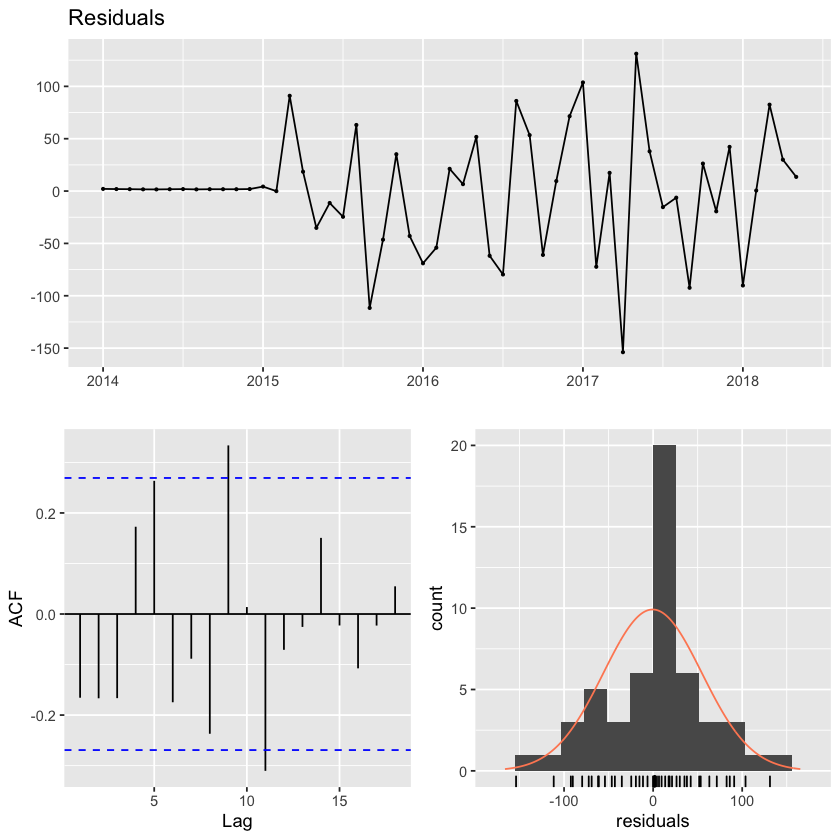

```r
# Save figure
png("figure/Figure 26 - Residuals : ARIMA with regression.png", width = 8, height = 9, units = 'in', res = 300)
checkresiduals(Arima.fit$residuals)
dev.off()

# Plot figure
checkresiduals(Arima.fit$residuals)
```

```r
shapiro.test(Arima.fit$residuals)
```

```
	Shapiro-Wilk normality test

data:  Arima.fit$residuals
W = 0.96934, p-value = 0.1889
```

The normality of the residues must be verified. Graphically, the residues seem to follow a normal distribution. A null hypothesis Shapiro-Wilk test is performed H0 (residues are normally distributed). We have a p-value> 5% which leads us to accept the hypothesis H0: the residues are normally distributed.

```r
Box.test.2(Arima.fit$residuals,nlag=c(6,12,18,24,30,36),type="Ljung-Box",decim=5)
```

A matrix: 6 × 2 of type dbl

| Retard | p-value |
| --- | --- |
| 6 | 0.08009 |
| 12 | 0.01090 |
| 18 | 0.06178 |
| 24 | 0.11500 |
| 30 | 0.25058 |
| 36 | 0.50609 |

Then, in the context of the ARMA models, it is desired that the residue be a white noise (low), that is to say without linear time dependence. Its covariances must be zero. On the ACF, we can notice that the majority of its simple autocorrelations (standardized covariances) are not significant. So graphically, the residue is a white noise. We do a null hypothesis Ljung-Box test H0 (the residues are a white noise). For the majority of lags, we have p-values> 5%, which leads us to partially accept the hypothesis H0.

```r
# The average DJU is calculated per month
DJU_mean <- aggregate(DJU ~ month, data_cons, mean)

# The prediction runs from June 2018 to May 2019. We reclassify the DJU_moyens according to this order.
temp1 <- DJU_mean[1:5,]
temp2 <- DJU_mean[6:12,]
temp3 <- rbind(temp2,temp1)

DJU_to_predict = ts(temp3['DJU'], start=c(2018, 6), end=c(2019, 5), frequency = 12)
DJU_to_predict
```

A Time Series: 2 × 12

|  | Jan | Feb | Mar | Apr | May | Jun | Jul | Aug | Sep | Oct | Nov | Dec |
| --- | --- | --- | --- | --- | --- | --- | --- | --- | --- | --- | --- | --- |
| 2018 |  |  |  |  |  | 25.525 | 8.525 | 16.275 | 44.900 | 132.200 | 224.800 | 317.075 |
| 2019 | 336.980 | 315.100 | 271.440 | 183.780 | 102.980 |  |  |  |  |  |  |  |

**pdf:** 2

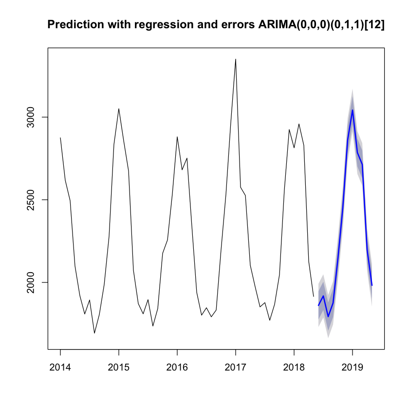

```r
fcast <- forecast(Arima.fit,xreg=DJU_to_predict)

# Save figure
png("figure/Figure 27 - Prediction with regression and errors ARIMA(0,0,0)(0,1,1)[12].png", width = 16, height = 9, units = 'in', res = 300)
plot(fcast, main="Prediction with regression and errors ARIMA(0,0,0)(0,1,1)[12]")
dev.off()

# Plot figure
plot(fcast, main="Prediction with regression and errors ARIMA(0,0,0)(0,1,1)[12]")
```

This part allows to treat the simple case where one would take into account an influential factor like the temperature to predict the consumption. This can obviously be extended with several influential variables.